# Building a Prediction Model for Weightlifting Activity Quality

## Loading libraries and reading in data

```r
library(ggplot2)
library(rpart)
library(rpart.plot)
library(caret)
library(ipred)
library(randomForest)
training <- read.csv("pml-training.csv", stringsAsFactors = F)
validation <- read.csv("pml-testing.csv", stringsAsFactors = F)
```

## Exploration

In exploring the training and validation sets it can be seen that there most of the variables in the sets have only NA values, therefore cannot be used so we will reduce the training set accordingly. There is no point in building a predictor which uses variables commonly not measured.

First we find those columns where NAs exist and assign them to a vector. Then we fill a vector with the names where NA values do NOT exist (keep). Then we create a new object called trainsmall which only contains the columns whose names are in the keep vector. We will also remove timestamps, the window columns and the numbering column X as these are not informative.

```r
missing <- apply(validation, 2, anyNA)
keep <- NULL
for(i in 1:160){
if(missing[i] == F) keep <- c(keep, names(training)[i])
}
trainsmall <- training[, names(training) %in% keep]
trainsmall$user_name <- as.factor(training$user_name)
trainsmall$classe <- as.factor(training$classe)
trainsmall <- trainsmall[, -c(1,3:7)]
```

As we are using the “testing” set provided as a validation set we will create an training and a test set from the “training” data

```r
set.seed(14232)
intrain <- createDataPartition(y=trainsmall$classe, p = 0.7, list = F)
train <- trainsmall[intrain,]
test <- trainsmall[-intrain,]
```

## Exploratory plotting

There are no variables with near zero variability so none to automatically exclude. A feature plot may show some patterns since some measurements are highly variable and others are not, standardising data is warranted before plotting. The y axis limits are still set to -10 and 10 otherwise much of the underlying variability is not seen for the scale. This plot shows some interesting points. The first is that it looks like many of the features are variable within “classe” rather than between “classe”. We can see that there are several features where E shows much more variability than the others, some where this only applies to D and some only to A.

```r
useless <- nearZeroVar(train, saveMetrics = T)
sum(useless$nzv)
```

```
## [1] 0
```

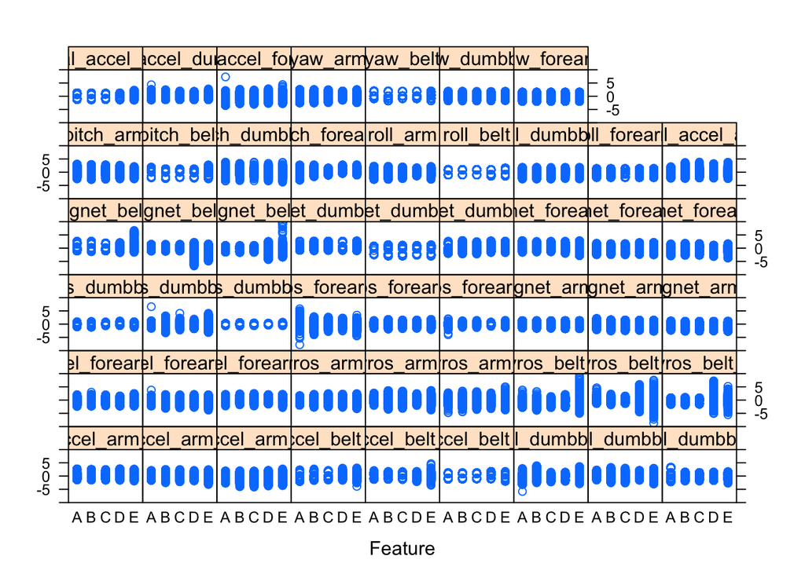

```r
trainstand <- as.data.frame(scale(train[,2:53]))
featurePlot(x = trainstand, y = train$classe, ylim = c(-10,10))
```

## Assessing redundancy

We should drop user_name as this is not a generalisable predictor.

It would almost certainly be safe to remove these variables as the correlation with other variables is strong but given that computational power is not particularly limited we should leave all of these factors in for maximum accuracy.

```r
train <- train[,2:54]
M <- abs(cor(train[,-53]))
diag(M) <- 0
correlated <- which(M>0.8, arr.ind=T)
correlated
```

```
##                  row col
## yaw_belt           3   1
## total_accel_belt   4   1
## accel_belt_y       9   1
## accel_belt_z      10   1
## accel_belt_x       8   2
## magnet_belt_x     11   2
## roll_belt          1   3
## roll_belt          1   4
## accel_belt_y       9   4
## accel_belt_z      10   4
## pitch_belt         2   8
## magnet_belt_x     11   8
## roll_belt          1   9
## total_accel_belt   4   9
## accel_belt_z      10   9
## roll_belt          1  10
## total_accel_belt   4  10
## accel_belt_y       9  10
## pitch_belt         2  11
## accel_belt_x       8  11
## gyros_arm_y       19  18
## gyros_arm_x       18  19
## magnet_arm_x      24  21
## accel_arm_x       21  24
## magnet_arm_z      26  25
## magnet_arm_y      25  26
## accel_dumbbell_x  34  28
## accel_dumbbell_z  36  29
## gyros_dumbbell_z  33  31
## gyros_forearm_z   46  31
## gyros_dumbbell_x  31  33
## gyros_forearm_z   46  33
## pitch_dumbbell    28  34
## yaw_dumbbell      29  36
## gyros_forearm_z   46  45
## gyros_dumbbell_x  31  46
## gyros_dumbbell_z  33  46
## gyros_forearm_y   45  46
```

```r
columns <- unique(correlated[,2])
names(train)[columns]
```

```
##  [1] "roll_belt"        "pitch_belt"       "yaw_belt"
##  [4] "total_accel_belt" "accel_belt_x"     "accel_belt_y"
##  [7] "accel_belt_z"     "magnet_belt_x"    "gyros_arm_x"
## [10] "gyros_arm_y"      "accel_arm_x"      "magnet_arm_x"
## [13] "magnet_arm_y"     "magnet_arm_z"     "pitch_dumbbell"
## [16] "yaw_dumbbell"     "gyros_dumbbell_x" "gyros_dumbbell_z"
## [19] "accel_dumbbell_x" "accel_dumbbell_z" "gyros_forearm_y"
## [22] "gyros_forearm_z"
```

## Principal components analysis

We can see if, instead, we run a principal components analysis on the data then we explain a lot of the variablility, by definition, but we do NOT explain the variability between “classe” groups which is the important thing. This is likely because there are recordings taken at many different times during the movement of lifting the weight and it is likely that most of the variability in the data is explained by differences in the phase of movement rather than the way it is done. This leads me to strongly suspect that a decision tree algorithm of some kind will be the best predictor.

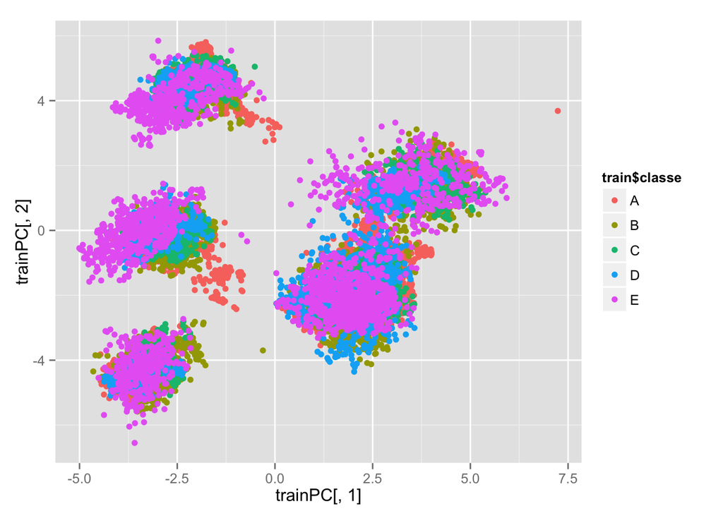

```r
PCA <- preProcess(train[,-53], method = "pca", pcaComp = 2)
trainPC <- predict(PCA, train[,-53])
qplot(trainPC[,1], trainPC[,2], colour = train$classe)
```

## Training the model

Confident that a tree method is going to be the most efficient and effective at differentiating the variable of interest we can go ahead and fit the model using a boosted tree model “gbm” which uses Stochastic Gradient Boosting. Cross validation is inherent in the method which should assure the greatest accuracy.

```r
modelfit <- train(classe ~ ., method = "gbm", verbose = F, data = train)
```

## Assessing the model on the training set

We can now assess the accuracy of the new predictor function on our training set. Accuracy of >95% will be sufficient. We can see that the accuracy is 97.4% (95% C.I. 97.1% - 97.6%) meaning an in-sample error rate of <3% which is excellent. We expect that our out-of-sample error rate will be higher but because of the cross-validation performed by the caret package in training the model the out-of-sample error rate should still be <5%

```r
predicted <- predict(modelfit, train[,-53])
confusionMatrix(predicted, train$classe)
```

```
## Confusion Matrix and Statistics
##
##           Reference
## Prediction    A    B    C    D    E
##          A 3860   60    0    0    4
##          B   31 2549   57    4   17
##          C   11   45 2313   55   17
##          D    2    4   21 2185   23
##          E    2    0    5    8 2464
##
## Overall Statistics
##
##                Accuracy : 0.9734
##                  95% CI : (0.9705, 0.976)
##     No Information Rate : 0.2843
##     P-Value [Acc > NIR] : < 2.2e-16
##
##                   Kappa : 0.9663
##  Mcnemar's Test P-Value : 3.821e-11
##
## Statistics by Class:
##
##                      Class: A Class: B Class: C Class: D Class: E
## Sensitivity            0.9882   0.9590   0.9654   0.9702   0.9758
## Specificity            0.9935   0.9902   0.9887   0.9956   0.9987
## Pos Pred Value         0.9837   0.9590   0.9476   0.9776   0.9939
## Neg Pred Value         0.9953   0.9902   0.9927   0.9942   0.9946
## Prevalence             0.2843   0.1935   0.1744   0.1639   0.1838
## Detection Rate         0.2810   0.1856   0.1684   0.1591   0.1794
## Detection Prevalence   0.2857   0.1935   0.1777   0.1627   0.1805
## Balanced Accuracy      0.9909   0.9746   0.9770   0.9829   0.9873
```

## Testing the model

We can now predict the test set based on this model and we find the accurary is still >96%. The error rate is higher than the in-sample error as we expected but is still acceptable at <5%.

```r
predictedtest <- predict(modelfit, test[2:53])
confusionMatrix(predictedtest, test$classe)
```

```
## Confusion Matrix and Statistics
##
##           Reference
## Prediction    A    B    C    D    E
##          A 1649   39    0    1    1
##          B   17 1076   34    1   12
##          C    3   22  979   31   11
##          D    4    1   13  924   14
##          E    1    1    0    7 1044
##
## Overall Statistics
##
##                Accuracy : 0.9638
##                  95% CI : (0.9587, 0.9684)
##     No Information Rate : 0.2845
##     P-Value [Acc > NIR] : < 2.2e-16
##
##                   Kappa : 0.9542
##  Mcnemar's Test P-Value : 1.423e-06
##
## Statistics by Class:
##
##                      Class: A Class: B Class: C Class: D Class: E
## Sensitivity            0.9851   0.9447   0.9542   0.9585   0.9649
## Specificity            0.9903   0.9865   0.9862   0.9935   0.9981
## Pos Pred Value         0.9757   0.9439   0.9359   0.9665   0.9915
## Neg Pred Value         0.9940   0.9867   0.9903   0.9919   0.9921
## Prevalence             0.2845   0.1935   0.1743   0.1638   0.1839
## Detection Rate         0.2802   0.1828   0.1664   0.1570   0.1774
## Detection Prevalence   0.2872   0.1937   0.1777   0.1624   0.1789
## Balanced Accuracy      0.9877   0.9656   0.9702   0.9760   0.9815
```

## Using the model on the validation set

Now we can move on to the validation set where the “classe” variable is unknown. This has been assigned to the variable “validation” at the beginning of the code. Since the conditions of the decision tree are named variables, there is no need to subset the validation frame by only the variable names used.

```r
answers <- as.character(predict(modelfit, validation))
pml_write_files = function(x){
  n = length(x)
  for(i in 1:n){
    filename = paste0("problem_id_",i,".txt")
    write.table(x[i],file=filename,quote=FALSE,row.names=FALSE,col.names=FALSE)
  }
}
setwd("answers")
pml_write_files(answers)
```